# si544-day6-more-basic-regression

Drew Pappas

10/11/2019

```r
library(tidyverse)
library(moderndive)
library(skimr)
```

```r
library(gapminder)
library(ggplot2)
```

## One categorical predictor variable

Let’s return to the Gapminder data:

```r
library(gapminder)
gapminder2007 <- gapminder %>% #Possible quiz question??
  filter(year == 2007) %>%
  select(country, lifeExp, continent, gdpPercap)
```

### Learning Check 544.6.1

What did the above code block do?

This code block runs the gapminder library to be usable and assigns the gapminder data set to a new variable called gapminder2007. The information entering gapminder 2007 is filtered down to only those values in 2007 and only the country, life expectancy, continent, and gdp per capita columns.

Let’s take a glimpse of the data:

```r
glimpse(gapminder2007)
```

```
## Observations: 142
## Variables: 4
## $ country   <fct> Afghanistan, Albania, Algeria, Angola, Argentina, Au...
## $ lifeExp   <dbl> 43.828, 76.423, 72.301, 42.731, 75.320, 81.235, 79.8...
## $ continent <fct> Asia, Europe, Africa, Africa, Americas, Oceania, Eur...
## $ gdpPercap <dbl> 974.5803, 5937.0295, 6223.3675, 4797.2313, 12779.379...
```

### Learning Check 544.6.2

Use skim() to get a “feel” for lifeExp and continent (Hint: look at last week’s notebook for a refresher of how to use “skim()”. What does the output tell you?

```r
gapminder2007 %>% select(lifeExp, continent) %>% skim()
```

```
## Skim summary statistics
##  n obs: 142
##  n variables: 2
##
## -- Variable type:factor -----------------------------------------------------------------------------
##   variable missing complete   n n_unique
##  continent       0      142 142        5
##                          top_counts ordered
##  Afr: 52, Asi: 33, Eur: 30, Ame: 25   FALSE
##
## -- Variable type:numeric ----------------------------------------------------------------------------
##  variable missing complete   n  mean    sd    p0   p25   p50   p75 p100
##   lifeExp       0      142 142 67.01 12.07 39.61 57.16 71.94 76.41 82.6
##      hist
##  ▂▂▂▂▂▃▇▇
```

This output provides us with the summary statistics for life expectancy and continent. The minimum life expectancy is 39.61 and the maximum is 82.6. The continent output provides us with the counts of each of the countries per continent and that there are 142 countries to be observed.

Let’s take a look at the distribution of worldwide life expectancies:

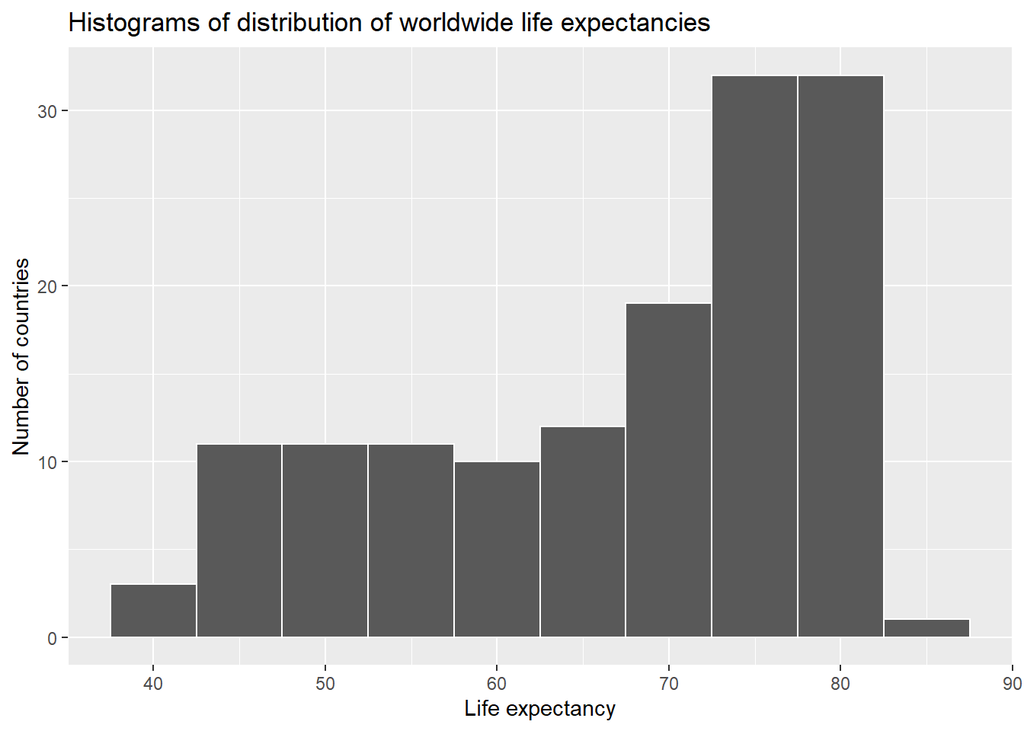

```r
ggplot(gapminder2007, aes(x = lifeExp)) +
  geom_histogram(binwidth = 5, color = "white") +
  labs(x = "Life expectancy", y = "Number of countries",
       title = "Histograms of distribution of worldwide life expectancies")
```

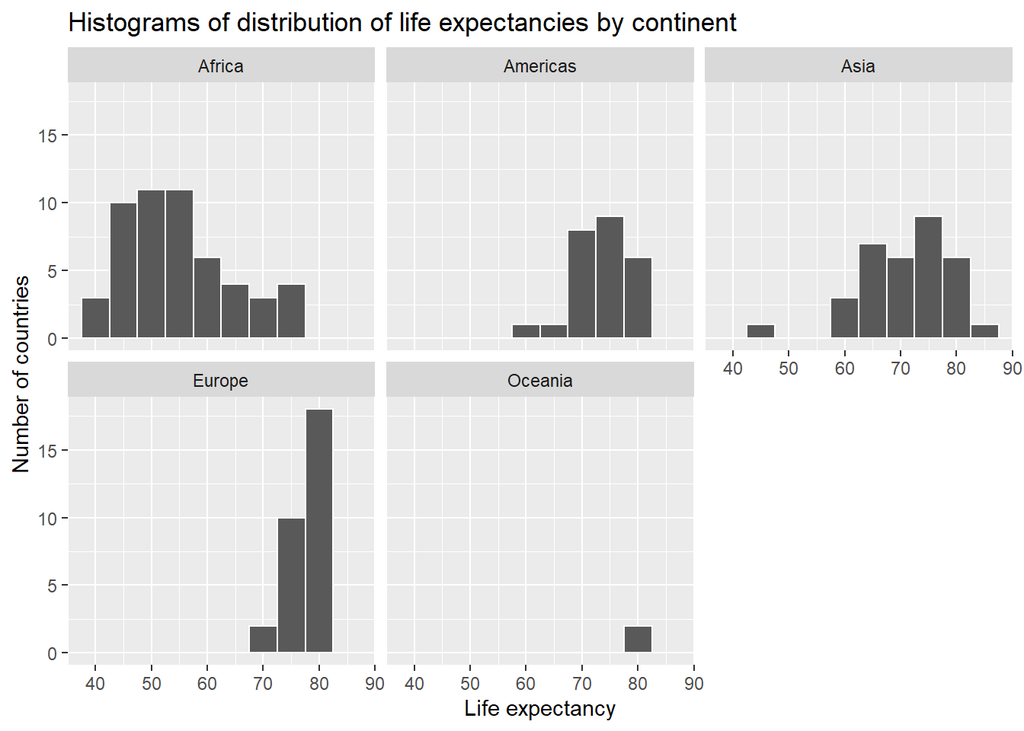

```r
ggplot(gapminder2007, aes(x = lifeExp)) +
  geom_histogram(binwidth = 5, color = "white") +
  labs(x = "Life expectancy", y = "Number of countries",
       title = "Histograms of distribution of life expectancies by continent") +
  facet_wrap(~ continent, nrow = 2) #review facet_wrap
```

And now let’s look at the same data with a boxplot:

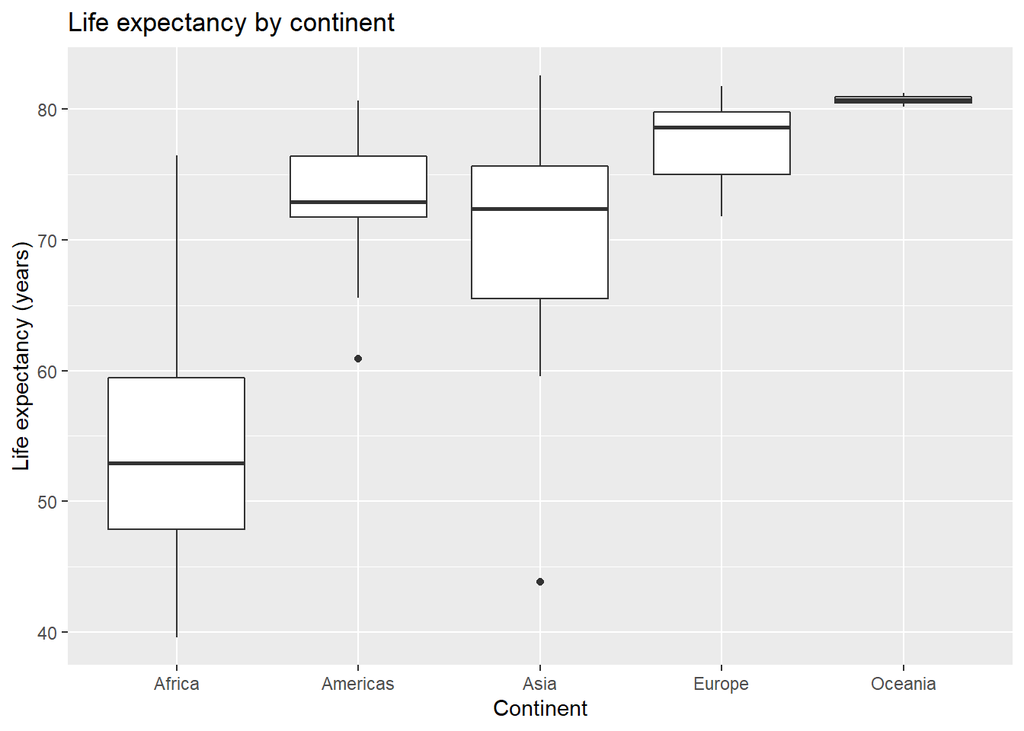

```r
ggplot(gapminder2007, aes(x = continent, y = lifeExp)) +
  geom_boxplot() +
  labs(x = "Continent", y = "Life expectancy (years)",
       title = "Life expectancy by continent")
```

```r
lifeExp_by_continent <- gapminder2007 %>%
  group_by(continent) %>%
  summarize(median = median(lifeExp), mean = mean(lifeExp))
lifeExp_by_continent
```

```
## # A tibble: 5 x 3
##   continent median  mean
##   <fct>      <dbl> <dbl>
## 1 Africa      52.9  54.8
## 2 Americas    72.9  73.6
## 3 Asia        72.4  70.7
## 4 Europe      78.6  77.6
## 5 Oceania     80.7  80.7
```

### Learning Check 544.6.3

Add a column called “deltaAfrica” to the lifeExp_by_continent dataframe that is calculated as the difference of each mean value from the mean value for Africa. Round your values to 1 decimal point. For example, the value for “Americas” should be 18.8.

```r
lifeExp_by_continent %>%
  mutate(deltaAfrica = round(mean - mean[1],1))
```

```
## # A tibble: 5 x 4
##   continent median  mean deltaAfrica
##   <fct>      <dbl> <dbl>       <dbl>
## 1 Africa      52.9  54.8         0
## 2 Americas    72.9  73.6        18.8
## 3 Asia        72.4  70.7        15.9
## 4 Europe      78.6  77.6        22.8
## 5 Oceania     80.7  80.7        25.9
```

Let’s fit a regression model to our categorical explanatory variable:

```r
# Fit regression model:
lifeExp_model <- lm(lifeExp ~ continent, data = gapminder2007)
# Get regression table:
get_regression_table(lifeExp_model)
```

```
## # A tibble: 5 x 7
##   term              estimate std_error statistic p_value lower_ci upper_ci
##   <chr>                <dbl>     <dbl>     <dbl>   <dbl>    <dbl>    <dbl>
## 1 intercept             54.8      1.02     53.4        0     52.8     56.8
## 2 continentAmericas     18.8      1.8      10.4        0     15.2     22.4
## 3 continentAsia         15.9      1.65      9.68       0     12.7     19.2
## 4 continentEurope       22.8      1.70     13.5        0     19.5     26.2
## 5 continentOceania      25.9      5.33      4.86       0     15.4     36.4
```

### Learning Check 544.6.4

How do the values of “estimate” compare to “deltaAfrica” from the earlier Learning Check?

They are the same values. The base line is the first value in the factored list. The regression table shows the deviation from the base value.

```r
get_regression_summaries(lifeExp_model)
```

```
## # A tibble: 1 x 8
##   r_squared adj_r_squared   mse  rmse sigma statistic p_value    df
##       <dbl>         <dbl> <dbl> <dbl> <dbl>     <dbl>   <dbl> <dbl>
## 1     0.635         0.625  52.8  7.26  7.40      59.7       0     5
```

### Learning Check 544.6.5

How “good” is this model?

On average, we will be incorrect in our prediction by 7.2 years. The p_value being low means the model can reasonably predict life expectancy. This model explains 62.5% of the variation within the data.

### Learning Check 544.6.6

Which Asian country has the most negative residual value? What does this tell you about this country?

```r
get_regression_points(lifeExp_model, ID='country') %>% filter(continent == 'Asia') %>% select(c('country','residual')) %>% arrange(residual)
```

```
## # A tibble: 33 x 2
##    country     residual
##    <fct>          <dbl>
##  1 Afghanistan   -26.9
##  2 Iraq          -11.2
##  3 Cambodia      -11.0
##  4 Myanmar        -8.66
##  5 Yemen, Rep.    -8.03
##  6 Nepal          -6.94
##  7 Bangladesh     -6.67
##  8 India          -6.03
##  9 Pakistan       -5.24
## 10 Mongolia       -3.92
## # ... with 23 more rows
```